# Modelling, Simulation and Control of Hydro-Power System - Part 6

Modeling the reaches using Python

2022-01-30T10:01:00

# Modular simulation of the reaches using DAE approach

In the previous posts I have shown how we can use differential algebraic equations to represent physical dynamics of a system. In this post we will continue building upon the code already developed in the previous posts of the series to be able to simulate a river as a series of reaches.

In part 3 of this series of post I’ve shown that the **De Saint Venant equations** can be used to describe the mass and momentum conservation of a hydrodynamic system. Considering a 1D system, these equations are:

$$\frac{\partial A}{\partial t} + \frac{\partial q}{\partial x} - q_{lat} = 0$$

$$\frac{\partial Q}{\partial t} + \frac{ \partial (\beta Q^2 / A)}{\partial x} +g A\left( \frac{\partial h}{\partial x} + S_f +S_e \right) - \beta q v_x + W_f B = 0$$
Each equation is a partial differential equation (PDE), which means that there are differential terms in respect to different variables. The term $\frac{\partial}{\partial x}$ represents a differential term with respect to the length (spatial) of the river. On the other hand, the term $\frac{\partial}{\partial t}$ represents a differential with respect to the time.

One way of dealing with PDEs is to discretize them in a set of ODEs, by replacing the spatial derivative ($\frac{\partial}{\partial x}$) by a finite difference term. By doing this there is no change in the way we are manipulating the problem as there are already ways of dealing with ODEs.

As an example, suppose we have a river reach section with total length $X$ meters. If I divide this reach in $N$ sections, then $dx$ becomes $\Delta x = \frac{X}{N}$. As described by Petrone (2010), to avoid stiffness and to properly model the system, the mass and momentum conservations are solved together by intersecting each other. In this way a river reach is made of sections, each section consisting in a “node” where mass conservation is solved (obtaining $A_n(t)$) and a “branch” where momentum conservation is solved (obtaining $Q_n(t)$), as shown in the following figure.

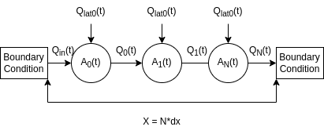

Spatialdiscretization.png

## Basic code

**Click to expand!**

```python
# imports
import numpy as np
import matplotlib.pyplot as plt
```

```python
model = Composite()
model.time = np.linspace(0, 8e4, 50)

# some constants
water = Material(rho=1000)

A = 16 # m2 area of tank
A_orifice = 5e-4 # m2

content_tank = Content(water, volume=10*A)
c = 0.62

#m0 = 10*A*RHO

# tank model
tank1 = Tank( model.time, A, content_tank)

# orifice model
orifice = Orifice(model.time, A_orifice, c)

model.tank1 = tank1
model.orifice = orifice
model.connect(tank1, orifice)
```

```python
sim = SimulationProblem(model)

result = sim.run()
model.change_inputs(result.x)
```

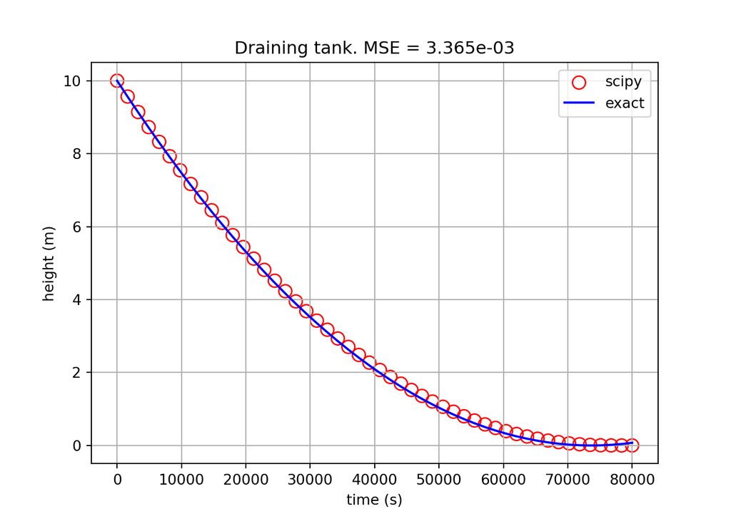

```python
def case1_exact(t):
    A_orifice = 5e-4
    A = 16.0
    h0 = 10.0
    t0 = 0.0
    c = 0.62
    g = 9.81
    h = (np.sqrt(h0) - A_orifice*c*np.sqrt(2*g)*(t-t0)/(2*A))**2
    return h

h_exact = case1_exact(model.time)

# Mean squared errors
MSE = np.mean((model.tank1.height() - h_exact)**2)

plt.scatter(model.time, model.tank1.height(), s=80, facecolors='none', edgecolors='r', label='scipy');
plt.plot( model.time, case1_exact(model.time),'b', label='exact')
plt.xlabel('time (s)')
plt.ylabel('height (m)')
plt.legend()
plt.title(f'Draining tank. MSE = {MSE:.3e}')
plt.grid()
plt.show()
```